# Guía Modelos Lineales Generales

Diplomado en Análisis de Datos con R e Investigación reproducible para Biociencias.

Dr. José A. Gallardo y Dra. María Angélica Rueda.

Pontificia Universidad Católica de Valparaíso  
jose.gallardo@pucv.cl

08 November 2022

### MODELOS LINEALES GENERALES

Los modelos lineales generales extienden a los modelos lineales clásicos admitiendo distribuciones no normales para la variable respuesta y modelando funciones de la media.

Los MLG son, por tanto, una extensión de los modelos lineales que permiten utilizar distribuciones no normales de los errores (binomiales, Poisson, gamma, etc) y varianzas no constantes.

Características de un modelo lineal general (MLG)

1). La variable respuesta/residuos pueden tener distribución normal u otros tipos de distribuciones.

2). Existencia de observaciones correlacionadas.

3). Puede existir heterogeneidad de varianzas.

Incumplimiento de los supuestos:

1. Hay observaciones correlacionadas.
2. Los residuos se pueden o no distribuir **normalmente**.
3. Varianza no constante.

#### **Objetivos de aprendizaje**

Los objetivos de aprendizaje de esta guía son:

**1**. - Ajustar modelos lineales generales.

**2**. - Realizar gráficas.

**3**. - Elaborar un reporte dinámico en formato html con **[Rmarkdown](https://rmarkdown.rstudio.com/)**.

## **Ejercicio 1.** Elaborar y configurar Reporte en formato .Rmd

Elabore un documento .Rmd y configure su reporte para exportar en html. Instale solo los paquetes que utilice para el análisis de los datos.

```r
knitr::opts_chunk$set(echo = TRUE)
library(readxl)
library(ggplot2)
library(multcomp)
library(psych)
library(car)
library(readr)
library(lmtest)
library(boot)
library(agridat)
```

Ejecute cada uno de los siguientes ejercicios en uno o más bloques de códigos diferentes. Sea ordenado y documente su reporte adecuadamente.

Complete la información de metadatos con: Título: Reporte modelo lineal general. Nombre del autor: Su nombre.

Luego guarde inmediatamente su *script* como **script_modelos_lineales_generales_nombre_apellido.Rmd**.

Ejecute cada uno de los siguientes ejercicios en uno o más bloques de códigos diferentes. Sea ordenado y documente su reporte adecuadamente.

## **Ejercicio 2.** Germinación de semillas con diferentes temperaturas y concentraciones

*mead.germination* es una base de datos del paquete **agridat** que se usará en este ejercicio. Es un dataframe con n=64 observaciones y con 5 variables cuya información es sobre germinación de semillas bajo diferentes temperaturas y concentraciones. Las variables son las siguientes:

- **temp:** temperature regimen.
- **rep:** replication factor (not blocking).
- **conc:** chemical concentration.
- **germ:** number of seeds germinating.
- **seeds:** number of seeds tested = 50.
1. Cargue la base de datos *mead.germination* usando el comando **data(mead.germination)**. Para guardar la base de datos como objeto debes ponerle un nombre por ejemplo, *dat <- mead.germination*. Realice el summary del objeto dat.

```
##  temp    rep          conc             germ           seeds
##  T1:16   R1:16   Min.   : 0.000   Min.   : 1.00   Min.   :50
##  T2:16   R2:16   1st Qu.: 0.075   1st Qu.: 7.00   1st Qu.:50
##  T3:16   R3:16   Median : 0.550   Median :13.50   Median :50
##  T4:16   R4:16   Mean   : 2.775   Mean   :18.30   Mean   :50
##                  3rd Qu.: 3.250   3rd Qu.:29.25   3rd Qu.:50
##                  Max.   :10.000   Max.   :49.00   Max.   :50
```

**b).** Ajuste un modelo nulo (**Regresión logística simple**) donde la variable respuesta será formada de la siguiente forma **cbind(germ, seeds-germ)** y no hay variable predictora, por lo que se debe colocar después de la variable respuesta lo siguiente **~ 1**. Use la función **glm()** y considere el argumento **family=binomial**. Realice el **summary()** del modelo.

```r
m0 <- glm(cbind(germ, seeds-germ) ~ 1, dat, family=binomial)
summary(m0)
```

```
##
## Call:
## glm(formula = cbind(germ, seeds - germ) ~ 1, family = binomial,
##     data = dat)
##
## Deviance Residuals:
##    Min      1Q  Median      3Q     Max
## -6.071  -3.572  -1.442   3.139   9.467
##
## Coefficients:
##             Estimate Std. Error z value Pr(>|z|)
## (Intercept)  -0.5497     0.0367  -14.98   <2e-16 ***
## ---
## Signif. codes:  0 '***' 0.001 '**' 0.01 '*' 0.05 '.' 0.1 ' ' 1
##
## (Dispersion parameter for binomial family taken to be 1)
##
##     Null deviance: 1193.8  on 63  degrees of freedom
## Residual deviance: 1193.8  on 63  degrees of freedom
## AIC: 1435.2
##
## Number of Fisher Scoring iterations: 3
```

**c).** Ajuste un modelo (**Regresión logística simple**) donde la variable respuesta será formada de la siguiente forma **cbind(germ, seeds-germ)** y **temp** como variable predictora. Use la función **glm()** y considere el argumento **family=binomial**. Realice el **summary()** del modelo.

```r
m1 <- glm(cbind(germ, seeds-germ) ~ temp, dat, family=binomial)
summary(m1)
```

```
##
## Call:
## glm(formula = cbind(germ, seeds - germ) ~ temp, family = binomial,
##     data = dat)
##
## Deviance Residuals:
##     Min       1Q   Median       3Q      Max
## -5.6471  -1.7835   0.0461   1.3676   6.6359
##
## Coefficients:
##             Estimate Std. Error z value Pr(>|z|)
## (Intercept) -0.37431    0.07195  -5.202 1.97e-07 ***
## tempT2       1.30640    0.10651  12.266  < 2e-16 ***
## tempT3      -1.78193    0.13646 -13.059  < 2e-16 ***
## tempT4      -0.80598    0.11014  -7.318 2.52e-13 ***
## ---
## Signif. codes:  0 '***' 0.001 '**' 0.01 '*' 0.05 '.' 0.1 ' ' 1
##
## (Dispersion parameter for binomial family taken to be 1)
##
##     Null deviance: 1193.80  on 63  degrees of freedom
## Residual deviance:  430.11  on 60  degrees of freedom
## AIC: 677.47
##
## Number of Fisher Scoring iterations: 4
```

**d).** Ajuste un modelo (**Regresión logísticamultiple**) donde la variable respuesta será formada de la siguiente forma **cbind(germ, seeds-germ)** y **temp**, **conc** como variables predictoras. Use la función **glm()** y considere el argumento **family=binomial**. Realice el **summary()** del modelo.

```r
m2 <- glm(cbind(germ, seeds-germ) ~ temp + conc, dat, family=binomial)
summary(m2)
```

```
##
## Call:
## glm(formula = cbind(germ, seeds - germ) ~ temp + conc, family = binomial,
##     data = dat)
##
## Deviance Residuals:
##     Min       1Q   Median       3Q      Max
## -4.5163  -1.3455   0.0403   1.8686   3.5231
##
## Coefficients:
##             Estimate Std. Error z value Pr(>|z|)
## (Intercept) -0.75360    0.08031  -9.383  < 2e-16 ***
## tempT2       1.38997    0.11030  12.602  < 2e-16 ***
## tempT3      -1.90019    0.14137 -13.441  < 2e-16 ***
## tempT4      -0.86894    0.11468  -7.577 3.53e-14 ***
## conc         0.13188    0.01026  12.858  < 2e-16 ***
## ---
## Signif. codes:  0 '***' 0.001 '**' 0.01 '*' 0.05 '.' 0.1 ' ' 1
##
## (Dispersion parameter for binomial family taken to be 1)
##
##     Null deviance: 1193.80  on 63  degrees of freedom
## Residual deviance:  256.89  on 59  degrees of freedom
## AIC: 506.24
##
## Number of Fisher Scoring iterations: 4
```

**e).** Compare los modelos de regresión logítica simple y múltiple de los items anteriores usando el críterio de AIC. Use la función **AIC()**. Diga según el criterio de AIC ¿Cuál sería el mejor modelo?

```
##    df       AIC
## m0  1 1435.1538
## m1  4  677.4662
## m2  5  506.2374
```

**f).** Compare los modelos de regresión logítica simple y múltiple de los items anteriores haciendo un anova. Use la función **anova(m0,m1,m2,test =‘Chisq’)**. Diga cuál sería el mejor modelo y porqué?

```
## Analysis of Deviance Table
##
## Model 1: cbind(germ, seeds - germ) ~ 1
## Model 2: cbind(germ, seeds - germ) ~ temp
## Model 3: cbind(germ, seeds - germ) ~ temp + conc
##   Resid. Df Resid. Dev Df Deviance  Pr(>Chi)
## 1        63    1193.80
## 2        60     430.11  3   763.69 < 2.2e-16 ***
## 3        59     256.89  1   173.23 < 2.2e-16 ***
## ---
## Signif. codes:  0 '***' 0.001 '**' 0.01 '*' 0.05 '.' 0.1 ' ' 1
```

## ESTUDIO DE CASO: PREDECIR RIESGO DE ATAQUE AL CORAZÓN.

En este estudio de caso trabajaremos con datos de un estudio cardiovascular de los residentes de la ciudad de Framingham, Massachusetts. [Fuente: Kaggle](https://www.kaggle.com/).

La variable respuesta se denomina **TenYearCHD = 10 year risk of coronary heart disease CHD** y es binaria (1 significa “Yes”, “0” significa “No”)** y las variables predictoras son:.

**Demographic:**.  
• Sex: male or female(Nominal).  
• Age: Age of the patient;(Continuous - Although the recorded ages have been truncated to whole numbers, the concept of age is continuous).

**Behavioral:**.  
• Current Smoker: whether or not the patient is a current smoker (Nominal).  
• Cigs Per Day: the number of cigarettes that the person smoked on average in one day.(can be considered continuous as one can have any number of cigarettes, even half a cigarette.).

**Medical:(history)**.  
• BP Meds: whether or not the patient was on blood pressure medication (Nominal).  
• Prevalent Stroke: whether or not the patient had previously had a stroke (Nominal).  
• Prevalent Hyp: whether or not the patient was hypertensive (Nominal).  
• Diabetes: whether or not the patient had diabetes (Nominal).

**Medical(current)**.  
• Tot Chol: total cholesterol level (Continuous).  
• Sys BP: systolic blood pressure (Continuous).  
• Dia BP: diastolic blood pressure (Continuous).  
• BMI: Body Mass Index (Continuous).  
• Heart Rate: heart rate (Continuous - In medical research, variables such as heart rate though in fact discrete, yet are considered continuous because of large number of possible values).  
• Glucose: glucose level (Continuous).

## **Ejercicio 3.** Exploratorio Heart attack dataset

Importe el set de datos **Heart_attack_dataset.xlsx** y realice un análisis exploratorio de datos.

Incluya:

**a).** Resumen estadístico de todas las variables con summary() y head().

```
##       male             age         education         currentSmoker
##  Min.   :0.0000   Min.   :32.00   Length:4238        Min.   :0.0000
##  1st Qu.:0.0000   1st Qu.:42.00   Class :character   1st Qu.:0.0000
##  Median :0.0000   Median :49.00   Mode  :character   Median :0.0000
##  Mean   :0.4292   Mean   :49.58                      Mean   :0.4941
##  3rd Qu.:1.0000   3rd Qu.:56.00                      3rd Qu.:1.0000
##  Max.   :1.0000   Max.   :70.00                      Max.   :1.0000
##   cigsPerDay           BPMeds          prevalentStroke     prevalentHyp
##  Length:4238        Length:4238        Min.   :0.000000   Min.   :0.0000
##  Class :character   Class :character   1st Qu.:0.000000   1st Qu.:0.0000
##  Mode  :character   Mode  :character   Median :0.000000   Median :0.0000
##                                        Mean   :0.005899   Mean   :0.3105
##                                        3rd Qu.:0.000000   3rd Qu.:1.0000
##                                        Max.   :1.000000   Max.   :1.0000
##     diabetes         totChol             sysBP              diaBP
##  Min.   :0.00000   Length:4238        Length:4238        Length:4238
##  1st Qu.:0.00000   Class :character   Class :character   Class :character
##  Median :0.00000   Mode  :character   Mode  :character   Mode  :character
##  Mean   :0.02572
##  3rd Qu.:0.00000
##  Max.   :1.00000
##      BMI             heartRate           glucose            TenYearCHD
##  Length:4238        Length:4238        Length:4238        Min.   :0.000
##  Class :character   Class :character   Class :character   1st Qu.:0.000
##  Mode  :character   Mode  :character   Mode  :character   Median :0.000
##                                                           Mean   :0.152
##                                                           3rd Qu.:0.000
##                                                           Max.   :1.000
```

```
## # A tibble: 6 × 16
##    male   age education current…¹ cigsP…² BPMeds preva…³ preva…⁴ diabe…⁵ totChol
##   <dbl> <dbl> <chr>         <dbl> <chr>   <chr>    <dbl>   <dbl>   <dbl> <chr>
## 1     1    39 4                 0 0       0            0       0       0 195
## 2     0    46 2                 0 0       0            0       0       0 250
## 3     1    48 1                 1 20      0            0       0       0 245
## 4     0    61 3                 1 30      0            0       1       0 225
## 5     0    46 3                 1 23      0            0       0       0 285
## 6     0    43 2                 0 0       0            0       1       0 228
## # … with 6 more variables: sysBP <chr>, diaBP <chr>, BMI <chr>,
## #   heartRate <chr>, glucose <chr>, TenYearCHD <dbl>, and abbreviated variable
## #   names ¹currentSmoker, ²cigsPerDay, ³prevalentStroke, ⁴prevalentHyp,
## #   ⁵diabetes
```

**b).** Ajuste un modelo lineal general (**Regresión logística simple**) donde la variable **TenYearCHD** es la variable respuesta y la variable **age** es la variable predictora. Use la función **glm()** y haga el **summary()** del modelo.

```r
modelo1 <- glm(TenYearCHD ~ age,
                family= binomial, data = Heart_data)
summary(modelo1)
```

```
##
## Call:
## glm(formula = TenYearCHD ~ age, family = binomial, data = Heart_data)
##
## Deviance Residuals:
##     Min       1Q   Median       3Q      Max
## -1.0384  -0.6262  -0.4582  -0.3697   2.4488
##
## Coefficients:
##              Estimate Std. Error z value Pr(>|z|)
## (Intercept) -5.558053   0.283790  -19.59   <2e-16 ***
## age          0.074598   0.005266   14.17   <2e-16 ***
## ---
## Signif. codes:  0 '***' 0.001 '**' 0.01 '*' 0.05 '.' 0.1 ' ' 1
##
## (Dispersion parameter for binomial family taken to be 1)
##
##     Null deviance: 3611.5  on 4237  degrees of freedom
## Residual deviance: 3396.3  on 4236  degrees of freedom
## AIC: 3400.3
##
## Number of Fisher Scoring iterations: 5
```

**c).** Realice el diagrama de dispersión de **TenYearCHD** v/s **age** usando la función geom_point() y use la función geom_smooth(method = “glm”, method.args = list(family = “binomial”)). Colocar título, nombre del eje x, nombre del eje y. Usar tema **theme_bw()**

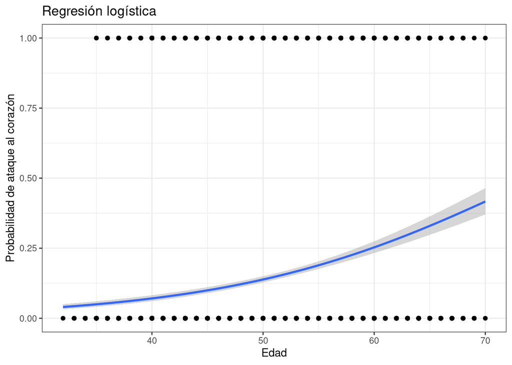

**d).** Ajuste un modelo lineal general (**Regresión logística múltiple**) donde la variable **TenYearCHD** es la variable respuesta y las variables **age** y **male** como variables predictoras. Use la función **glm()** y haga el **summary()** del modelo.

```
##
## Call:
## glm(formula = TenYearCHD ~ age + male, family = binomial, data = Heart_data)
##
## Deviance Residuals:
##     Min       1Q   Median       3Q      Max
## -1.1422  -0.6175  -0.4647  -0.3465   2.5609
##
## Coefficients:
##              Estimate Std. Error z value Pr(>|z|)
## (Intercept) -5.913745   0.293048  -20.18  < 2e-16 ***
## age          0.076371   0.005312   14.38  < 2e-16 ***
## male         0.560748   0.088723    6.32 2.61e-10 ***
## ---
## Signif. codes:  0 '***' 0.001 '**' 0.01 '*' 0.05 '.' 0.1 ' ' 1
##
## (Dispersion parameter for binomial family taken to be 1)
##
##     Null deviance: 3611.5  on 4237  degrees of freedom
## Residual deviance: 3356.2  on 4235  degrees of freedom
## AIC: 3362.2
##
## Number of Fisher Scoring iterations: 5
```

**e).** Compare los modelos de regresión logítica simple y múltiple de los items anteriores usando el críterio de AIC. Use la función **AIC()**. Diga según el criterio de AIC ¿Cuál sería el mejor modelo?

```
##         df      AIC
## modelo1  2 3400.326
## modelo2  3 3362.181
```

**f).** Compare los modelos de regresión logítica simple y múltiple de los items anteriores haciendo un anova. Use la función **anova(modelo1, modelo2,test =‘Chisq’)**. Diga cuál sería el mejor modelo y porqué?

```
## Analysis of Deviance Table
##
## Model 1: TenYearCHD ~ age
## Model 2: TenYearCHD ~ age + male
##   Resid. Df Resid. Dev Df Deviance  Pr(>Chi)
## 1      4236     3396.3
## 2      4235     3356.2  1   40.145 2.358e-10 ***
## ---
## Signif. codes:  0 '***' 0.001 '**' 0.01 '*' 0.05 '.' 0.1 ' ' 1
```

## **Ejercicio 4.** Ajuste de forma libre otros modelos lineales generales de Regresión logística múltiple

**a).** Considere al menos el modelo completo donde la variable **TenYearCHD** es la variable respuesta y todas las otras variables son las variables predictoras. Use la función **glm()** y haga el **summary()** del modelo completo.

**b).** ¿Puede descartar alguna variable del modelo completo porque no es significativa?.

**d).** Realice diagramas de dispersión de **TenYearCHD** v/s otras variables predictoras que son significativas.